# Structural Equation Modeling | Lab Session 1

# 1 Lab sessions: why and how?

1. Apply theoretical knowledge
2. Increase understanding by interacting with data
3. Learn to use some packages in R
4. How:
   - Relatively unstructured
   - Go at your own pace, try to do the exercises yourself (do yourself a favour and do not just copy paste and run the solutions)
   - “There is never time to do it right, but there is always time to do it over”

## 1.1 Software used: **R**

```
- This is not an R course!
- We will learn some R as we go along
- I will use RStudio
- Many packages or libraries exist to do specific analyses
```

# 2 What we are going to cover

1. R environment preparation
2. Data preparation and exploration
3. Exercise 1 - correlation and covariance matrix for the welfare criticism items

# 3 Data

The data set used throughout is the European Social Survey ESS4-2008 Edition 4.5 was released on 1 December 2018. We will restrict the analysis to the Belgian case. Each line in the data set represents a Belgian respondent. The full dataset an documentation can be found on the [ESS website](https://www.europeansocialsurvey.org/data/download.html?r=4)

Codebook:

- **gvslvol** Standard of living for the old, governments’ responsibility (0 Not governments’ responsibility at all - 10 Entirely governments’ responsibility)
- **gvslvue** Standard of living for the unemployed, governments’ responsibility (0 Not governments’ responsibility at all - 10 Entirely governments’ responsibility)
- **gvhlthc** Health care for the sick, governments’ responsibility (0 Not governments’ responsibility at all - 10 Entirely governments’ responsibility)
- **gvcldcr** Child care services for working parents, governments’ responsibility (0 Not governments’ responsibility at all - 10 Entirely governments’ responsibility)
- **gvjbevn** Job for everyone, governments’ responsibility (0 Not governments’ responsibility at all - 10 Entirely governments’ responsibility)
- **gvpdlwk** Paid leave from work to care for sick family, governments’ responsibility (0 Not governments’ responsibility at all - 10 Entirely governments’ responsibility)
- **sbstrec** Social benefits/services place too great strain on economy (1 Agree strongly - 5 Disagree strongly)
- **sbbsntx** Social benefits/services cost businesses too much in taxes/charges (1 Agree strongly - 5 Disagree strongly)
- **sbprvpv** Social benefits/services prevent widespread poverty (1 Agree strongly - 5 Disagree strongly)
- **sbeqsoc** Social benefits/services lead to a more equal society (1 Agree strongly - 5 Disagree strongly)
- **sbcwkfm** Social benefits/services make it easier to combine work and family (1 Agree strongly - 5 Disagree strongly)
- **sblazy** Social benefits/services make people lazy (1 Agree strongly - 5 Disagree strongly)
- **sblwcoa** Social benefits/services make people less willing care for one another (1 Agree strongly - 5 Disagree strongly)
- **sblwlka** Social benefits/services make people less willing look after themselves/family (1 Agree strongly - 5 Disagree strongly)
- **agea** Respondent’s age
- **eduyrs** Years of full-time education completed
- **gndr** Gender (1 Male, 2 Female)
- **hinctnta** Household’s total net income, all sources (Deciles of the actual household income range in the given country.)
- **gincdif** Government should reduce differences in income levels (1 Agree strongly - 5 Disagree strongly)
- **dfincac** Large differences in income acceptable to reward talents and efforts (1 Agree strongly - 5 Disagree strongly)
- **smdfslv** For fair society, differences in standard of living should be small (1 Agree strongly - 5 Disagree strongly)

# 4 Environment preparation

First, let’s load the necessary packages to load, manipulate, visualize and analyse the data.

```r
# Uncomment this once if you need to install the packages on your system

### DATA MANIPULATION ###
# install.packages("haven")                 # data import from spss
# install.packages("dplyr")                 # data manipulation
# install.packages("psych")                 # descriptives
# install.packages("stringr")               # string manipulation

### MODELING ###
# install.packages("lavaan")                # SEM modelling

### VISUALIZATION ###
# install.packages("tidySEM")               # plotting SEM models
# install.packages("corrplot")              # correlation/covariance plots


# Load the packages

### DATA MANIPULATION ###
library("haven")
library("dplyr")
library("psych")
library('stringr')

### MODELING ###
library("lavaan")

### VISUALIZATION ###
library("corrplot")
library("tidySEM")
```

You can look at the documentation of evert R packageor function using the ?name_of_package or ?name_of_the_function

```r
# check the lavaan help page
?lavaan
# check the cfa function help page
?cfa
```

# 5 Data exploration

It is a good practice to check that everything is in order and make sense of the data that we are going to analyze.

```r
ess_df <- haven::read_sav("https://github.com/albertostefanelli/SEM_labs/raw/master/ESS4_belgium.sav")

head(ess_df, 20)  # first 20 rows of the dataset
```

```
# A tibble: 20 x 21
               gvslvol             gvslvue             gvhlthc  gvcldcr             gvjbevn  gvpdlwk         sbstrec        sbbsntx        sbprvpv        sbeqsoc        sbcwkfm         sblazy        sblwcoa        sblwlka   agea eduyrs    gndr    hinctnta        gincdif        dfincac        smdfslv
             <dbl+lbl>           <dbl+lbl>           <dbl+lbl> <dbl+lb>           <dbl+lbl> <dbl+lb>       <dbl+lbl>      <dbl+lbl>      <dbl+lbl>      <dbl+lbl>      <dbl+lbl>      <dbl+lbl>      <dbl+lbl>      <dbl+lbl> <dbl+> <dbl+> <dbl+l>   <dbl+lbl>      <dbl+lbl>      <dbl+lbl>      <dbl+lbl>
 1  8 [8]               7 [7]               8 [8]                 5 [5]  8 [8]                 5 [5] 2 [Agree]       1 [Agree stro… 1 [Agree stro… 3 [Neither ag… 2 [Agree]      2 [Agree]      2 [Agree]      2 [Agree]          36     18 1 [Mal…  4 [M - 4t… 2 [Agree]      3 [Neither ag… 2 [Agree]
 2  7 [7]               7 [7]               8 [8]                 7 [7]  7 [7]                 6 [6] 4 [Disagree]    3 [Neither ag… 2 [Agree]      2 [Agree]      2 [Agree]      4 [Disagree]   4 [Disagree]   4 [Disagree]       26     15 2 [Fem…  7 [K - 7t… 2 [Agree]      3 [Neither ag… 2 [Agree]
 3  6 [6]               3 [3]               6 [6]                 5 [5]  3 [3]                 4 [4] 2 [Agree]       2 [Agree]      3 [Neither ag… 4 [Disagree]   3 [Neither ag… 1 [Agree stro… 1 [Agree stro… 1 [Agree stro…     69     18 1 [Mal… 10 [H - 10… 4 [Disagree]   1 [Agree stro… 4 [Disagree]
 4  6 [6]               6 [6]               6 [6]                 6 [6]  3 [3]                 3 [3] 3 [Neither agr… 2 [Agree]      2 [Agree]      2 [Agree]      2 [Agree]      3 [Neither ag… 2 [Agree]      2 [Agree]          77     15 2 [Fem…  7 [K - 7t… 2 [Agree]      2 [Agree]      2 [Agree]
 5  6 [6]               4 [4]               7 [7]                 5 [5]  6 [6]                 5 [5] 4 [Disagree]    1 [Agree stro… 2 [Agree]      2 [Agree]      2 [Agree]      4 [Disagree]   3 [Neither ag… 3 [Neither ag…     27     13 1 [Mal…  7 [K - 7t… 3 [Neither ag… 4 [Disagree]   4 [Disagree]
 6 10 [Entirely gover…  5 [5]              10 [Entirely gover…    5 [5]  5 [5]                 7 [7] 3 [Neither agr… 2 [Agree]      2 [Agree]      2 [Agree]      3 [Neither ag… 2 [Agree]      4 [Disagree]   4 [Disagree]       32     12 2 [Fem…  6 [S - 6t… 4 [Disagree]   2 [Agree]      4 [Disagree]
 7 10 [Entirely gover…  6 [6]               8 [8]                 6 [6]  8 [8]                 6 [6] 4 [Disagree]    2 [Agree]      2 [Agree]      4 [Disagree]   3 [Neither ag… 4 [Disagree]   3 [Neither ag… 4 [Disagree]       19     13 2 [Fem…  8 [P - 8t… 4 [Disagree]   2 [Agree]      2 [Agree]
 8  7 [7]               6 [6]               9 [9]                 7 [7]  8 [8]                 8 [8] 4 [Disagree]    3 [Neither ag… 2 [Agree]      2 [Agree]      2 [Agree]      3 [Neither ag… 4 [Disagree]   4 [Disagree]       28     17 2 [Fem… 10 [H - 10… 2 [Agree]      3 [Neither ag… 2 [Agree]
 9  9 [9]               6 [6]               9 [9]                 5 [5]  5 [5]                 8 [8] 2 [Agree]       3 [Neither ag… 3 [Neither ag… 2 [Agree]      3 [Neither ag… 2 [Agree]      2 [Agree]      3 [Neither ag…     49     16 1 [Mal…  4 [M - 4t… 1 [Agree stro… 4 [Disagree]   2 [Agree]
10  8 [8]               8 [8]               8 [8]                 8 [8]  8 [8]                 8 [8] 4 [Disagree]    3 [Neither ag… 2 [Agree]      2 [Agree]      3 [Neither ag… 3 [Neither ag… 4 [Disagree]   3 [Neither ag…     57     16 1 [Mal…  9 [D - 9t… 2 [Agree]      2 [Agree]      3 [Neither ag…
11  8 [8]               6 [6]               8 [8]                 7 [7]  6 [6]                 6 [6] 2 [Agree]       2 [Agree]      2 [Agree]      4 [Disagree]   4 [Disagree]   2 [Agree]      2 [Agree]      2 [Agree]          71     17 2 [Fem…  7 [K - 7t… 4 [Disagree]   4 [Disagree]   3 [Neither ag…
12  8 [8]               6 [6]               8 [8]                 8 [8]  7 [7]                 7 [7] 1 [Agree stron… 3 [Neither ag… 4 [Disagree]   4 [Disagree]   3 [Neither ag… 3 [Neither ag… 2 [Agree]      2 [Agree]          83     16 2 [Fem…  8 [P - 8t… 3 [Neither ag… 2 [Agree]      2 [Agree]
```

[output cut: 8 more lines]

```r
nrow(ess_df)      # number of subjects
```

```
[1] 1760
```

```r
ncol(ess_df)      # number of variables
```

```
[1] 21
```

```r
names(ess_df)     # names of variables
```

```
 [1] "gvslvol"  "gvslvue"  "gvhlthc"  "gvcldcr"  "gvjbevn"  "gvpdlwk"  "sbstrec"  "sbbsntx"  "sbprvpv"  "sbeqsoc"  "sbcwkfm"  "sblazy"   "sblwcoa"  "sblwlka"  "agea"     "eduyrs"   "gndr"     "hinctnta" "gincdif"  "dfincac"  "smdfslv"
```

In this first lab, we are exploring two concepts: welfare support and welfare criticism. Let’s take a closer look at our items

```r
ess_df_selected <- ess_df %>% select(
                  ## Welfare support items ##
                  gvslvol, # the old
                  gvslvue, # the unemployed
                  gvhlthc, # the sick
                  gvcldcr, # working parents
                  gvjbevn, # job for everyone
                  gvpdlwk, # paid sick leave
                  ##    Economic criticism items ##
                  sbstrec, # strain on economy
                  sbbsntx, # too much taxes
                  ##    Social criticism items ##
                  sbprvpv, # poverty
                  sbeqsoc, # more equal society
                  sbcwkfm, # work and family
                  ##    Moral criticism items ##
                  sblazy,  # people lazy
                  sblwcoa, # care for others
                  sblwlka  # look after others
)

descriptive_ess <- as.data.frame(psych::describe(ess_df_selected))

descriptive_ess <- dplyr::select(descriptive_ess,
  n,
  mean,
  sd,
  median,
  min,
  max,
  skew,
  kurtosis)

descriptive_ess
```

```
           n     mean        sd median min max        skew    kurtosis
gvslvol 1759 7.871518 1.4811986      8   0  10 -0.78122430  1.37621274
gvslvue 1753 6.059897 1.9176408      6   0  10 -0.40989634  0.40781515
gvhlthc 1757 8.030734 1.4715101      8   0  10 -0.94788987  1.81361522
gvcldcr 1748 7.276316 1.7622804      7   0  10 -0.80981813  1.34667552
gvjbevn 1756 6.234624 2.2667339      7   0  10 -0.48699173 -0.08302998
gvpdlwk 1753 7.310325 1.7677965      8   0  10 -0.82684920  1.31394820
sbstrec 1735 2.963112 1.0193172      3   1   5  0.10310828 -0.92138250
sbbsntx 1714 2.531505 0.9970179      2   1   5  0.42532526 -0.51782206
sbprvpv 1740 2.333908 0.8722280      2   1   5  0.85304303  0.41061715
sbeqsoc 1748 2.374714 0.8341462      2   1   5  0.94680277  0.68051829
sbcwkfm 1735 2.334870 0.7775840      2   1   5  0.98878599  0.95302935
sblazy  1751 2.894917 1.0557772      3   1   5  0.10529513 -0.92067158
sblwcoa 1751 2.919475 1.0352766      3   1   5  0.06846687 -1.05077060
sblwlka 1746 2.981672 1.0339269      3   1   5 -0.09401127 -1.07498593
```

Before getting into more complex modelling, it is worth checking the structure of the data by calculating the variance-covariance matrix for some of the items that we are going to use later. Let’s first start with the items measuring welfare support.

```r
# let's select the welfare support items

ess_df_welfare_supp <- ess_df %>% select(
                  ## Welfare support items ##
                  gvslvol, # the old
                  gvslvue, # the unemployed
                  gvhlthc, # the sick
                  gvcldcr, # working parents
                  gvjbevn, # job for everyone
                  gvpdlwk  # paid sick leave
)

# let's calculate the sample implied covariance matrix
welfare_supp_cov <- cov(ess_df_welfare_supp,          # data frame
                        use = "pairwise.complete.obs" # remove NAs
                        )

welfare_supp_cov
```

```
          gvslvol   gvslvue   gvhlthc   gvcldcr  gvjbevn   gvpdlwk
gvslvol 2.1939494 0.8998156 1.3524399 1.0333956 1.203299 1.0712067
gvslvue 0.8998156 3.6773463 0.8016763 0.7827062 1.488233 0.8159548
gvhlthc 1.3524399 0.8016763 2.1653419 0.8897580 1.287510 0.9485565
gvcldcr 1.0333956 0.7827062 0.8897580 3.1056322 1.231219 1.6873857
gvjbevn 1.2032994 1.4882330 1.2875099 1.2312188 5.138083 1.1656366
gvpdlwk 1.0712067 0.8159548 0.9485565 1.6873857 1.165637 3.1251045
```

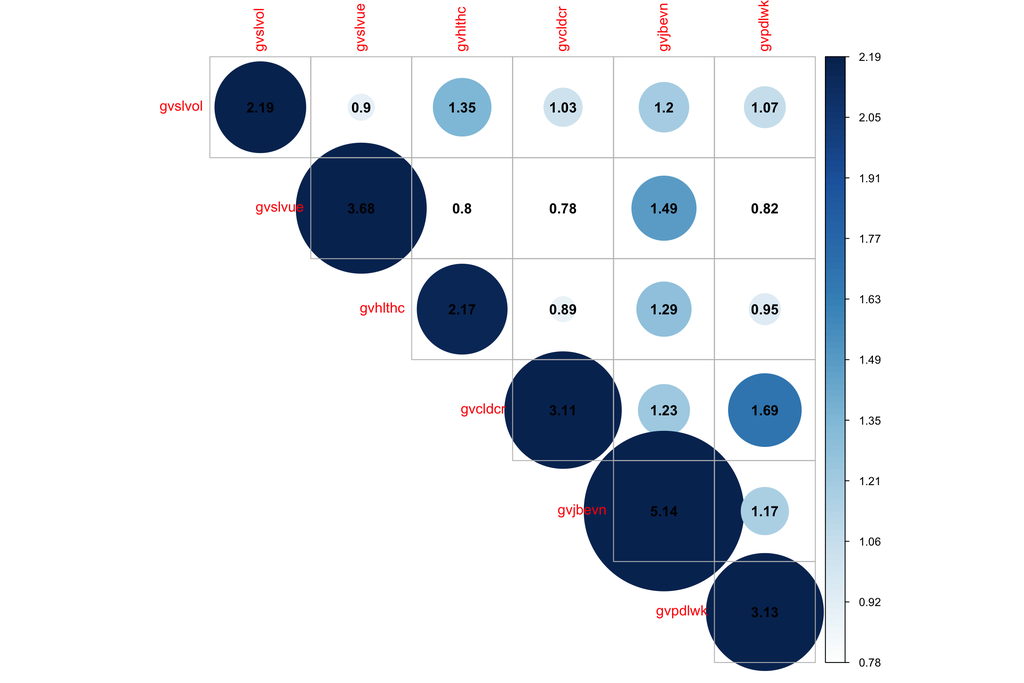

```r
# visual inspection is sometimes more useful
# we can use the corrplot package.

corrplot::corrplot(welfare_supp_cov,
                    is.corr = FALSE,       # whether is a correlation matrix
                    method = "circle",     # magnitude of covariances as circles
                    type = "upper",        # remove the bottom of the covariance matrix
                    addCoef.col = "black"  # add to the plot the coefficients
 )
```

```r
# but can also be used for correlation matrix
# transform the covariance matrix to a correlation matrix and plot it.
welfare_supp_cor <- cov2cor(welfare_supp_cov)
welfare_supp_cor
```

```
          gvslvol   gvslvue   gvhlthc   gvcldcr   gvjbevn   gvpdlwk
gvslvol 1.0000000 0.3167911 0.6204995 0.3958934 0.3583933 0.4090983
gvslvue 0.3167911 1.0000000 0.2840982 0.2316096 0.3423759 0.2406947
gvhlthc 0.6204995 0.2840982 1.0000000 0.3431102 0.3859995 0.3646428
gvcldcr 0.3958934 0.2316096 0.3431102 1.0000000 0.3082192 0.5416354
gvjbevn 0.3583933 0.3423759 0.3859995 0.3082192 1.0000000 0.2908911
gvpdlwk 0.4090983 0.2406947 0.3646428 0.5416354 0.2908911 1.0000000
```

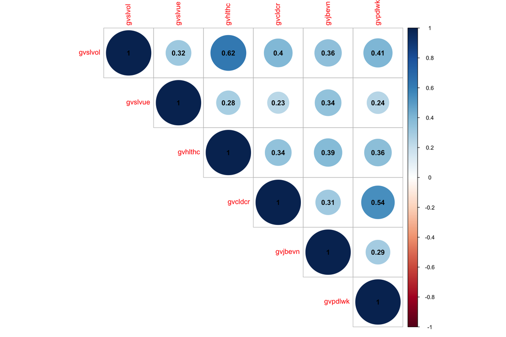

```r
corrplot::corrplot(welfare_supp_cor,
                    is.corr = TRUE,        # whether is a correlation matrix
                    method = "circle",     # magnitude of covariances as circles
                    type = "upper",        # remove the bottom of the covariance matrix
                    addCoef.col = "black"  # add to the plot the coefficients
 )
```

# 6 Exercise 1 - correlation and covariance matrix

Use R to get familiar with the syntax and perform the following tasks:

1. Load the R packages
2. Load and explore the data
3. Calculate the correlation matrix for all the welfare criticism items
4. Calculate the covariance matrix for all the welfare criticism items
5. Interpret the output and the figures.

```r
# let's select the welfare criticism items

ess_df_welfare_crit<- ess_df %>% select(
                  ##    Economic criticism items ##
                  sbstrec, # strain on economy
                  sbbsntx, # too much taxes
                  ##    Social criticism items ##
                  sbprvpv, # poverty
                  sbeqsoc, # more equal society
                  sbcwkfm, # work and family
                  ##    Moral criticism items ##
                  sblazy,  # people lazy
                  sblwcoa, # care for others
                  sblwlka  # look after others
)
# continue on your own : )
```

# 7 References

[^1]: [Alberto Stefanelli](https://albertostefanelli.com/)
[^2]: [Ahu Alanya](https://www.kuleuven.be/wieiswie/en/person/00081320)
[^3]: [Bart Meuleman](https://www.kuleuven.be/wieiswie/en/person/00041613)